# DS400: Assignment V (R)

Simon Andres (Student ID: 4148078)

2023-01-31

Note: I worked together with Christopher Forschner and Janik Müller (exchanged some ideas)

### Setting up a new GitHub repository

1./2./3./4. GitHub setup: registration, initializing repository, documentation of process

The GitHub setup was done, all steps of this project are documented in my repository, follow this link: https://github.com/Studymon/DSPM_Assignment5

### Getting to know the API

5. Visit the documentation website for the API provided by ticketmaster.com. Familiarize yourself with the features and functionalities of the Ticketmaster *Discovery* API. Have a particular look at rate limits.

I made myself familiar with the Ticketmaster Discovery API and understand that there is a rate limit of max. 5 requests per second and a maximum number of daily requests of 5000.

6. Within the scope of this assignment, you do **not** have to request your own API key. Instead retrieve a valid key from the API Explorer. This API key enables you to perform the `GET` requests needed throughout this assignment. Even though this API key is not secret per se (it is publicly visible on the API Explorer website), please comply to the common secrecy practices discussed in the lecture and the tutorial: Treat the API key as a **secret** token. Your API key should neither appear in the code that you are submitting nor in your public GitHub repository.

To comply with the common secrecy practices, the key was stored in a separate script that is stored in a subfolder `api_keys` excluded from syncing with the GitHub repository through the `.gitignore` file.

```r
# Preparation
rm(list = ls())

# Libraries
library(jsonlite)
library(httr)
library(rlist)
library(tidyverse)
```

```r
# source the ticketmaster key from separate script
source("./api_keys/tm_key.R")
```

### Interacting with the API - the basics

7. Perform a first `GET` request, that searches for event venues in Germany (`countryCode = "DE"`). Extract the `content` from the `response` object and inspect the resulting list. Describe what you can see.

```r
# make request
firstVenues <- GET("https://app.ticketmaster.com/discovery/v2/venues.json?",
                     query = list(
                        apikey = tm_key,
                       "countryCode" = "DE",
                       "locale" = "*")
                   )

# make unicode readable
firstVenues <- content(firstVenues)

summary(firstVenues)
```

```
##           Length Class  Mode
## _embedded 1      -none- list
## _links    4      -none- list
## page      4      -none- list
```

Our request from the ticketmaster API contains three lists: `_embedded`, `_links`, and `page`.

First, we’ll look at the page structure:

```r
firstVenues[["page"]]
```

```
## $size
## [1] 20
##
## $totalElements
## [1] 12935
##
## $totalPages
## [1] 647
##
## $number
## [1] 0
```

We see that for our request there is a total of 12935 elements. However, our specific request only yields the first 20 results, as that is the default number of search results per page for the ticketmaster API. Thus, there are 647 pages in total. The first page index is zero.

```r
summary(firstVenues[["_embedded"]])
```

```
##        Length Class  Mode
## venues 20     -none- list
```

We see that the list `_embedded` contains the list `venues`, which contains information about a total of 20 venues, the first 20 results (first page).

Now, we’ll look at what information we get on the first element:

```r
str(firstVenues[["_embedded"]][["venues"]][[1]])
```

```
## List of 19
##  $ name          : chr "Grosse Freiheit 36"
##  $ type          : chr "venue"
##  $ id            : chr "KovZpZAn6vEA"
##  $ test          : logi FALSE
##  $ url           : chr "http://www.ticketmaster.de/venue/287636"
##  $ locale        : chr "en-de"
##  $ images        :List of 1
##   ..$ :List of 5
##   .. ..$ ratio   : chr "16_9"
##   .. ..$ url     : chr "https://s1.ticketm.net/dbimages/962v."
##   .. ..$ width   : int 205
##   .. ..$ height  : int 115
##   .. ..$ fallback: logi FALSE
##  $ postalCode    : chr "22767"
##  $ timezone      : chr "Europe/Berlin"
##  $ city          :List of 1
##   ..$ name: chr "Hamburg"
##  $ country       :List of 2
##   ..$ name       : chr "Germany"
##   ..$ countryCode: chr "DE"
##  $ address       :List of 1
##   ..$ line1: chr "Grosse Freiheit 36"
##  $ location      :List of 2
##   ..$ longitude: chr "9.957905"
##   ..$ latitude : chr "53.551187"
##  $ markets       :List of 1
##   ..$ :List of 2
##   .. ..$ name: chr "Germany"
##   .. ..$ id  : chr "210"
##  $ dmas          :List of 1
##   ..$ :List of 1
##   .. ..$ id: int 610
##  $ boxOfficeInfo :List of 1
##   ..$ phoneNumberDetail: chr "Telefon tagsüber: (040) 31 77 78- 0 Große Freiheit 36 22767 Hamburg E-Mail: info@grossefreiheit36.de"
##  $ upcomingEvents:List of 3
##   ..$ _total   : int 1
##   ..$ mfx-de   : int 1
##   ..$ _filtered: int 0
##  $ ada           :List of 3
##   ..$ adaPhones    : chr "+49.(0)1805 - 969 0000 (14 Ct./Min.)"
##   ..$ adaCustomCopy: chr "Sollten Sie besondere Sitzplatzwünsche haben, prüfen Sie bitte die Informationsseite des Veranstaltungsortes. F"| __truncated__
##   ..$ adaHours     : chr "Montag bis Freitag, in der Zeit von 9.00-19.00 Uhr sowie sonnabends von 10.00-18.00 Uhr zur Verfügung."
##  $ _links        :List of 1
##   ..$ self:List of 1
##   .. ..$ href: chr "/discovery/v2/venues/KovZpZAn6vEA?locale=en-de"
```

We see that for the first result, we get information on multiple properties of the venue: Name, type, ID, … Some of this information is stored in strings, some of it is stored in further sublists.

8. Extract the `name`, the `city`, the `postalCode` and `address`, as well as the `url` and the `longitude` and `latitude` of the venues to a data frame.

```r
# looking at the structure above, we see how to access each of these elements

# store number of results per page in n_perPage
n_perPage <- firstVenues[["page"]]$size

# initiate df
firstVenues_df <- tibble(
  name = character(n_perPage),
  city = character(n_perPage),
  postalCode = double(n_perPage),
  address = character(n_perPage),
  url = character(n_perPage),
  longitude = double(n_perPage),
  latitude = double(n_perPage),
)

# retrieve information by iterating over all entries of page
for (i in 1:n_perPage){
  # name
  firstVenues_df[i,1] <- firstVenues[["_embedded"]][["venues"]][[i]]$name
  # city
  firstVenues_df[i,2] <- firstVenues[["_embedded"]][["venues"]][[i]]$city %>% unlist()
  # postal code
  firstVenues_df[i,3] <- firstVenues[["_embedded"]][["venues"]][[i]]$postalCode %>% as.double()
  # address
  firstVenues_df[i,4] <- firstVenues[["_embedded"]][["venues"]][[i]]$address %>% unlist()
  # url
  firstVenues_df[i,5] <- firstVenues[["_embedded"]][["venues"]][[i]]$url
  # longitude
  firstVenues_df[i,6] <- firstVenues[["_embedded"]][["venues"]][[i]]$location$longitude %>% as.double()
  # latitude
  firstVenues_df[i,7] <- firstVenues[["_embedded"]][["venues"]][[i]]$location$latitude %>% as.double()
}

firstVenues_df
```

```
## # A tibble: 20 × 7
##    name                       city         posta…¹ address url   longi…² latit…³
##    <chr>                      <chr>          <dbl> <chr>   <chr>   <dbl>   <dbl>
##  1 Grosse Freiheit 36         Hamburg        22767 Grosse… http…    9.96    53.6
##  2 Gruenspan                  Hamburg        22767 Grosse… http…    9.96    53.6
##  3 Huxleys Neue Welt          Berlin         10967 Hasenh… http…   13.4     52.5
##  4 Zentrum am Park            Emmelshausen   56281 Rhein-… http…    7.56    50.2
##  5 Stadthalle (Theatersaal)   Mülheim        45479 Theodo… http…    6.87    51.4
##  6 Schlossgarten              Bruchsal       76646 Schlos… http…    8.60    49.1
##  7 Stadthalle                 Hockenheim     68766 Rathau… http…    8.55    49.3
##  8 FZW                        Dortmund       44263 Ritter… http…    7.45    51.5
##  9 Arena Trier                Trier          54292 Fort-W… http…    6.66    49.8
## 10 Eissporthalle              Memmingen      87700 Hühner… http…   10.2     48.0
## 11 Stadthalle Gersthofen      Gersthofen     86368 Rathau… http…   10.9     48.4
## 12 Feierwerk (Kranhalle)      Munich         81373 Hansas… http…   11.5     48.1
## 13 Feierwerk (Hansa 39)       Munich         81373 Hansas… http…   11.5     48.1
## 14 Burghof - STIMMEN-Festival Lörrach        79539 Herren… http…    7.66    47.6
## 15 Schiesssportanlage         Neu Wulmsto…   21629 Wesenb… http…    9.80    53.5
## 16 WUNDERINO ARENA            Kiel           24103 Europa… http…   10.1     54.3
## 17 Stadtpark Open Air         Hamburg        22303 Saarla… http…   10.0     53.6
## 18 Laeiszhalle (Großer Saal)  Hamburg        20355 Johann… http…    9.98    53.6
## 19 Friedrich-Ebert-Halle      Hamburg        21075 Alter … http…    9.97    53.5
## 20 myticket Jahrhunderthalle  Frankfurt a…   65929 Pfaffe… http…    8.52    50.1
## # … with abbreviated variable names ¹postalCode, ²longitude, ³latitude
```

→ The dataframe looks as intended. There is one row for each entry (i.e. each venue), so 20 in total, and 7 columns for the venue properties we wanted to extract.

### Interacting with the API - advanced

9. Have a closer look at the list element named `page`. Did your `GET` request from exercise (7) return *all* event locations in Germany? Obviously not - there are of course much more venues in Germany than those contained in this list. Your `GET` request only yielded the first results page containing the first 20 out of several thousands of venues. Check the API documentation under the section *Venue Search*. How can you request the venues from the remaining results pages? Iterate over the results pages and perform `GET` requests for all venues in Germany. After each iteration, extract the seven variables `name`, `city`, `postalCode`, `address`, `url`, `longitude`, and `latitude`. Join the information in one large data frame. Print the first 10 rows and the shape of the resulting data frame.

```r
# As it is really inefficient to do the GET request over and over, the data
# frame is exported at the end of this code chunk once
# Then the chunk is muted

# re-do first request
first400Venues <- GET("https://app.ticketmaster.com/discovery/v2/venues.json?",
                     query = list(
                        apikey = tm_key,
                       "countryCode" = "DE",
                       "locale" = "*",
                       "size" = 400)
                   )

# make unicode readable
first400Venues <- content(first400Venues)

# store number of total results in n
n <- first400Venues[["page"]]$totalElements

# store number of pages in n_pages
n_pages <- first400Venues[["page"]]$totalPages

# initiate df collecting all venues in Germany
venuesGER <- tibble(
  name = character(n),
  city = character(n),
  postalCode = double(n),
  address = character(n),
  url = character(n),
  longitude = double(n),
  latitude = double(n),
)

x = 1
faultyPages <- 0

# Loop
for (i in 1:n_pages) {

  # enforce rate limit
  Sys.sleep(0.2)

  # store results of each page temporarily
  tempResults <- GET("https://app.ticketmaster.com/discovery/v2/venues.json?",
                     query = list(
                        apikey = tm_key,
                       "countryCode" = "DE",
                       "locale" = "*",
                       "size" = 400,
                       "page" = i-1)
                   )
  # check the status code
  if (status_code(tempResults) != 200) {

    # adjust current row in df, add to faultyPages counter
    x <- x + 1
    faultyPages <- faultyPages + 1

    # skip the current iteration of the for loop
    next
  }

  tempResults <- content(tempResults)

  for (j in 1:tempResults[["page"]]$size) {
    # name
    venuesGER[x,1] <- tempResults[["_embedded"]][["venues"]][[j]]$name
    # city
    venuesGER[x,2] <-
      ifelse("city" %in% names(tempResults[["_embedded"]][["venues"]][[j]]),
             tempResults[["_embedded"]][["venues"]][[j]]$city %>% unlist(),
             NA)
    # postal code (missing for some --> NA)
    venuesGER[x,3] <-
      ifelse("postalCode" %in% names(tempResults[["_embedded"]][["venues"]][[j]]),
             tempResults[["_embedded"]][["venues"]][[j]]$postalCode %>% as.double(),
             NA)
    # address (missing for some --> NA)
    venuesGER[x,4] <-
      ifelse(
        "address" %in% names(tempResults[["_embedded"]][["venues"]][[j]]) &
          !is.null(tempResults[["_embedded"]][["venues"]][[j]]$address$line1) &
          tempResults[["_embedded"]][["venues"]][[1]]$address %>% unlist() %>% is.character(),
        tempResults[["_embedded"]][["venues"]][[j]]$address %>% unlist(),
        NA
      )
    # url
    venuesGER[x,5] <-
      ifelse("url" %in% names(tempResults[["_embedded"]][["venues"]][[j]]),
             tempResults[["_embedded"]][["venues"]][[j]]$url,
             NA)

    # longitude and latitude is missing for many venues, so give NA accordingly
    if("location" %in% names(tempResults[["_embedded"]][["venues"]][[j]])) {
      venuesGER[x,6] <- tempResults[["_embedded"]][["venues"]][[j]]$location$longitude %>% as.double()
      venuesGER[x,7] <- tempResults[["_embedded"]][["venues"]][[j]]$location$latitude %>% as.double()
    }
    else {
      venuesGER[x,6] <- NA
      venuesGER[x,7] <- NA
    }

    # jump to next row in results df
    x = x + 1
  }

}

# Export
write_csv(venuesGER, "./venuesGER.csv")
```

```r
# read in the previously exported venuesGER data
venuesGER <- read_csv("./venuesGER.csv")
```

```r
head(venuesGER)
```

```
## # A tibble: 6 × 7
##   name                     city         postalCode address url   longi…¹ latit…²
##   <chr>                    <chr>             <dbl> <chr>   <chr>   <dbl>   <dbl>
## 1 Grosse Freiheit 36       Hamburg           22767 Grosse… http…    9.96    53.6
## 2 Gruenspan                Hamburg           22767 Grosse… http…    9.96    53.6
## 3 Huxleys Neue Welt        Berlin            10967 Hasenh… http…   13.4     52.5
## 4 Zentrum am Park          Emmelshausen      56281 Rhein-… http…    7.56    50.2
## 5 Stadthalle (Theatersaal) Mülheim           45479 Theodo… http…    6.87    51.4
## 6 Schlossgarten            Bruchsal          76646 Schlos… http…    8.60    49.1
## # … with abbreviated variable names ¹longitude, ²latitude
```

The data frame is filled with it 12,935 observations, missing properties were successfully marked with NAs.

### Visualizing the extracted data

10./11. Below, you can find code that produces a map of Germany. Add points to the map indicating the locations of the event venues across Germany.

```r
# NA count prior
is.na(venuesGER$longitude) %>% sum()
```

```
## [1] 4407
```

```r
# first, give the faulty coordinates NA's
faulty_coordinates <- venuesGER$longitude < 5.866 | venuesGER$longitude > 15.042 |
                      venuesGER$latitude < 47.270 | venuesGER$latitude > 55.059

# set invalid coordinates to NA
venuesGER$longitude[faulty_coordinates] <- NA
venuesGER$latitude[faulty_coordinates] <- NA

# NA count after
is.na(venuesGER$longitude) %>% sum()
```

```
## [1] 4496
```

We removed 89 (4496 - 4407) observations with faulty coordinates

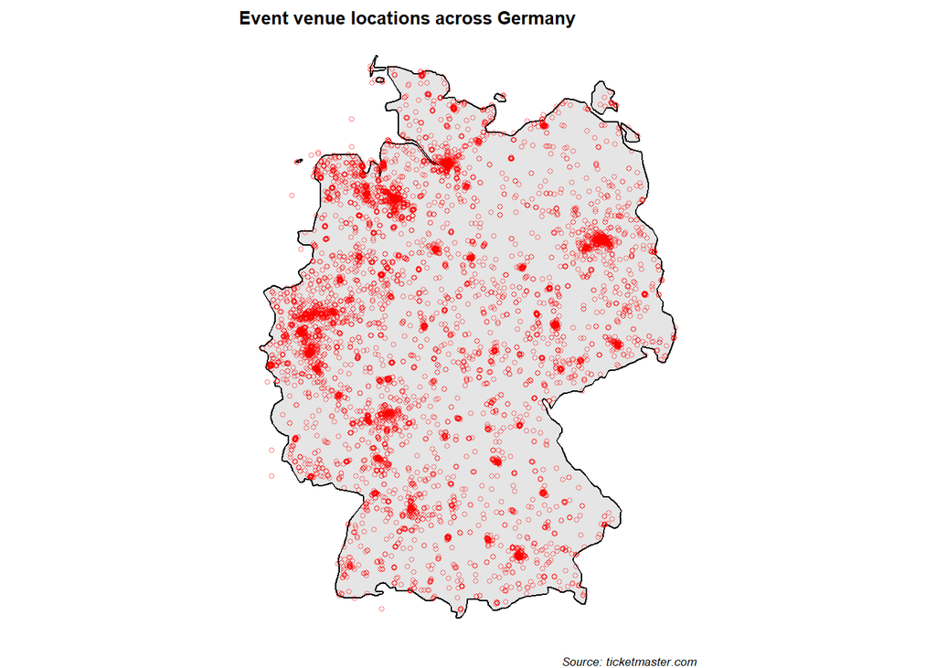

```r
# adjust plot (add points and format)
ggplot() +
  borders("world", "Germany", colour = "black", fill = "grey90") +
  theme_void() +
  coord_quickmap() +
  geom_point(data = venuesGER, aes(x = longitude, y = latitude), color = "red", shape = 21, size = 1, alpha = 0.5) +
  labs(title = "Event venue locations across Germany",
       caption = "Source: ticketmaster.com") +
  theme(title = element_text(size=8, face='bold'),
        plot.caption = element_text(face = "italic"))
```

→ The map looks as expected, we see more venues at more populated areas (e.g.: Cologne/Berlin/Hamburg/Stuttgart/Munich)

### Event locations in other countries

12. Repeat exercises (9) - (11) for another European country of your choice.

```r
# make single request
firstVenues_DK <- GET("https://app.ticketmaster.com/discovery/v2/venues.json?",
                     query = list(
                        apikey = tm_key,
                       "countryCode" = "DK",
                       "locale" = "*",
                       "size" = 400)
                   )

# make unicode readable
firstVenues_DK <- content(firstVenues_DK)
# store number of total results in n
n_DK <- firstVenues_DK[["page"]]$totalElements

# store number of pages in n_pages
n_pages_DK <- firstVenues_DK[["page"]]$totalPages

# initiate df collecting all venues in Denmark
venuesDK <- tibble(
  name = character(n_DK),
  city = character(n_DK),
  postalCode = double(n_DK),
  address = character(n_DK),
  url = character(n_DK),
  longitude = double(n_DK),
  latitude = double(n_DK),
)

x = 1
faultyPages <- 0

# Loop
for (i in 1:n_pages) {

  # enforce rate limit
  Sys.sleep(0.2)

  # store results of each page temporarily
  tempResults <- GET("https://app.ticketmaster.com/discovery/v2/venues.json?",
                     query = list(
                        apikey = tm_key,
                       "countryCode" = "DK",
                       "locale" = "*",
                       "size" = 400,
                       "page" = i-1)
                   )
  # check the status code
  if (status_code(tempResults) != 200) {

    # adjust current row in df, add to faultyPages counter
    x <- x + 1
    faultyPages <- faultyPages + 1

    # skip the current iteration of the for loop
    next
  }

  tempResults <- content(tempResults)

  for (j in 1:tempResults[["page"]]$size) {
    # name
    venuesDK[x,1] <- tempResults[["_embedded"]][["venues"]][[j]]$name
    # city
    venuesDK[x,2] <-
      ifelse("city" %in% names(tempResults[["_embedded"]][["venues"]][[j]]),
             tempResults[["_embedded"]][["venues"]][[j]]$city %>% unlist(),
             NA)
    # postal code (missing for some --> NA)
    venuesDK[x,3] <-
      ifelse("postalCode" %in% names(tempResults[["_embedded"]][["venues"]][[j]]),
             tempResults[["_embedded"]][["venues"]][[j]]$postalCode %>% as.double(),
             NA)
    # address (missing for some --> NA)
    venuesDK[x,4] <-
      ifelse(
        "address" %in% names(tempResults[["_embedded"]][["venues"]][[j]]) &
          !is.null(tempResults[["_embedded"]][["venues"]][[j]]$address$line1) &
          tempResults[["_embedded"]][["venues"]][[1]]$address %>% unlist() %>% is.character(),
        tempResults[["_embedded"]][["venues"]][[j]]$address %>% unlist(),
        NA
      )
    # url
    venuesDK[x,5] <-
      ifelse("url" %in% names(tempResults[["_embedded"]][["venues"]][[j]]),
             tempResults[["_embedded"]][["venues"]][[j]]$url,
             NA)

    # longitude and latitude is missing for many venues, so give NA accordingly
    if("location" %in% names(tempResults[["_embedded"]][["venues"]][[j]])) {
      venuesDK[x,6] <- tempResults[["_embedded"]][["venues"]][[j]]$location$longitude %>% as.double()
      venuesDK[x,7] <- tempResults[["_embedded"]][["venues"]][[j]]$location$latitude %>% as.double()
    }
    else {
      venuesDK[x,6] <- NA
      venuesDK[x,7] <- NA
    }

    # jump to next row in results df
    x = x + 1
  }

}

# Export
write_csv(venuesDK, "./venuesDK.csv")
```

```r
# read in the previously exported venuesDK data
venuesDK <- read_csv("./venuesDK.csv")
```

```r
# NA count prior
is.na(venuesDK$longitude) %>% sum()
```

```
## [1] 39
```

```r
# first, give the faulty coordinates NA's
faulty_coordinatesDK <- venuesDK$longitude < 8.0725 | venuesDK$longitude > 15.1972 |
                        venuesDK$latitude < 54.5833 | venuesDK$latitude > 57.7525

# set invalid coordinates to NA
venuesDK$longitude[faulty_coordinatesDK] <- NA
venuesDK$latitude[faulty_coordinatesDK] <- NA

# NA count after
is.na(venuesDK$longitude) %>% sum()
```

```
## [1] 39
```

We removed no additional observations for Denmark.

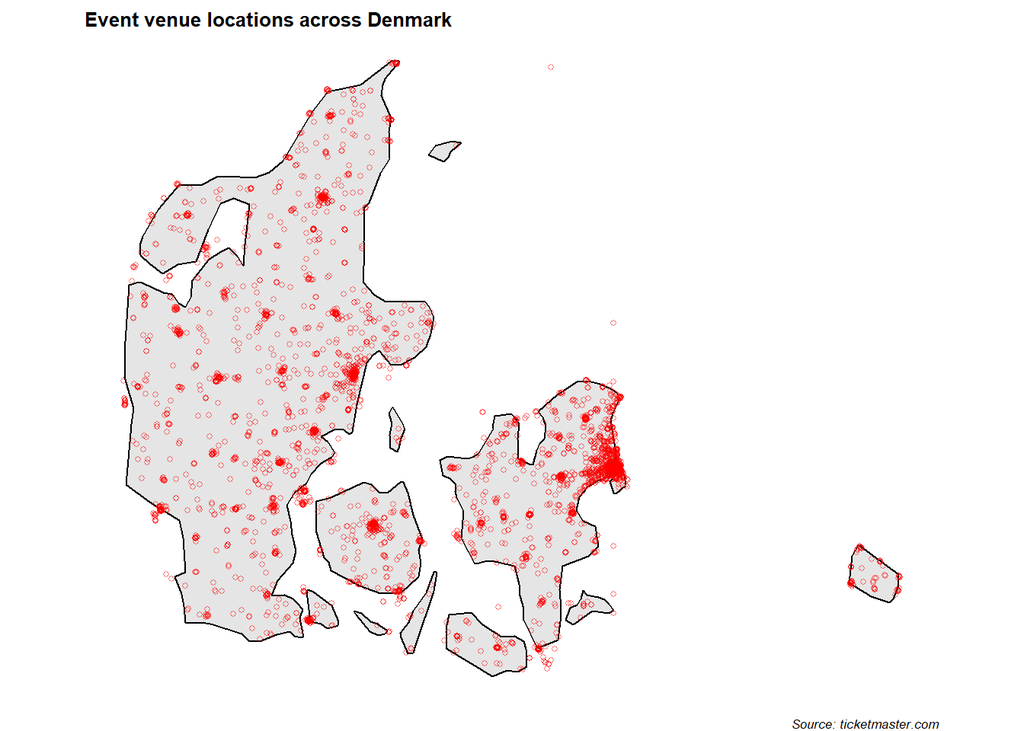

```r
# adjust plot (add points and format)
ggplot() +
  borders("world", "Denmark", colour = "black", fill = "grey90") +
  theme_void() +
  coord_quickmap() +
  geom_point(data = venuesDK, aes(x = longitude, y = latitude), color = "red", shape = 21, size = 1, alpha = 0.5) +
  labs(title = "Event venue locations across Denmark",
       caption = "Source: ticketmaster.com") +
  theme(title = element_text(size=8, face='bold'),
        plot.caption = element_text(face = "italic"))
```

→ The map looks as expected, we see more venues at more populated areas (e.g.: Kopenhagen in the east)